# The macroecology of rodent synanthropy

Authors

David Simons

Colin Carlson

Daniel Becker

Barbara Han

Rory Gibb

Steph Seifert

Published

September 5, 2024

# Motivation

Produce a nice raster for a model on plague.

# Methods

1. *Identify a problem*. Based on known synanthropic rodent species’ are we able to predict synanthropy as a trait for all rodents?
2. *Develop or obtain outcome data*. Synanthropy is the outcome, previously compiled for rodents in this paper by [Ecke et al.](https://www.nature.com/articles/s41467-022-35273-7). See table below for synanthropy status for species (unsure what TS means).
3. *Develop or obtain predictor data*. To be confirmed based on a review of current literature but likely to include;
   1. Morphological traits (i.e., body size, tail length)
   2. Ecological traits (i.e., diet composition, habitat preference, nesting habits)
   3. Behavioural traits (i.e., activity patterns, social structure, aggressiveness)
   4. Life history traits (i.e., reproductive rate, longevity)
   5. Physiological traits (i.e., thermoregulation, disease resistance)
   6. Human associated traits (i.e., anthropogenic food availability, tolerance)
   7. Biome/range size
   8. Human population density within rodent range (predictor or effect?)
   9. Genetic relatedness to established synanthropic species/diversity within population (?increased adaptability)
   10. Climate

[figure not shown]

Predicting synanthropy for a rodent species

4. *Data harmonisation*
5. *Feature selection*
6. *BRT*
7. *Interpreting predictions*. Binary classification synanthropic (1) or non-synanthropic (0) for each rodent species.
8. *Validation*
9. *Sensitivity*
10. *Visualisation*
11. *Transparency and reporting*
12. *Model updating*
13. *Model retirement*

## Data

### Rodent species

```r
rodentia <- read_csv(here("data", "mammal_diversity", "MDD_v1.12.1.csv")) %>%
  filter(order == "RODENTIA")
synanthropy <- read_xlsx(here("data", "rodent_synanthropy", "ecke_2022.xlsx")) %>%
  select(Rodents, Synanthropic)
cyclicity <- read_xlsx(here("data", "rodent_synanthropy", "ecke_2022.xlsx")) %>%
  select(Rodents, Synanthropic, Urban_areas, Cyclicity) %>%
  drop_na(Cyclicity) %>%
  distinct(Rodents, Synanthropic, Urban_areas, Cyclicity)
```

There are 2732 rodent species recorded in the [ASM Mammal Diversity Database v1.12.1](https://www.mammaldiversity.org/).

### Known synanthropy

```r
synanthropy_df <- rodentia %>%
  select(sciName, genus, family, order) %>%
  left_join(synanthropy, by = c("sciName" = "Rodents")) %>%
  distinct()

synanthropy_df %>%
  mutate(sciName = str_replace(sciName, "_", " "),
         family = str_to_sentence(family),
         order = str_to_sentence(order)) %>%
  rename("Scientific name" = sciName) %>%
  datatable(colnames = str_to_sentence(names(.)))
```

|  | Scientific name | Genus | Family | Order | Synanthropic |
| --- | --- | --- | --- | --- | --- |
| 1 | Ctenodactylus gundi | Ctenodactylus | Ctenodactylidae | Rodentia | O |
| 2 | Ctenodactylus vali | Ctenodactylus | Ctenodactylidae | Rodentia |  |
| 3 | Felovia vae | Felovia | Ctenodactylidae | Rodentia |  |
| 4 | Massoutiera mzabi | Massoutiera | Ctenodactylidae | Rodentia |  |
| 5 | Pectinator spekei | Pectinator | Ctenodactylidae | Rodentia |  |
| 6 | Laonastes aenigmamus | Laonastes | Diatomyidae | Rodentia |  |
| 7 | Cavia aperea | Cavia | Caviidae | Rodentia | N |
| 8 | Cavia fulgida | Cavia | Caviidae | Rodentia |  |
| 9 | Cavia intermedia | Cavia | Caviidae | Rodentia |  |
| 10 | Cavia magna | Cavia | Caviidae | Rodentia |  |

[output cut: 2725 more lines]

From these we have information on synanthropy from 389 (14%) species. Of which 130 are classed as synanthropic and 253 as non-synanthropic. A small subset (6 species), are classed as “TS”.

### Rodent phylogeny

Synanthropic and nonsynanthropic species that share a recent common ancestor may exhibit higher genetic similarity compared to more distantly related species. In the context of synanthropy, divergent evolution may result in genetic differences between synanthropic and nonsynanthropic species due to adaptation to urban or anthropogenic environments versus natural habitats. Convergent evolution may lead to genetic similarities between synanthropic species from different evolutionary lineages that have independently adapted to human-altered environments. Genes that confer fitness advantages in anthropogenic settings are likely to be under positive selection in synanthropic species. Traits associated with increased fitness in anthropogenic environments, such as tolerance to urbanization, ability to exploit human resources, or resistance to anthropogenic stressors (e.g., pollution, habitat fragmentation), may be encoded by genes that are enriched or fixed in synanthropic populations.

```r
# rodent_tree <- treeio::read.nexus(here("data", "rodent_phylogeny", "output.nex"))
#
# rodent_tree_1 <- as_tibble(rodent_tree[[1]]) %>%
#   left_join(synanthropy_df %>%
#               select("label" = sciName, Synanthropic)) %>%
#   as.phylo()
#
# tree_viz <- as.phylo(rodent_tree_1) %>%
#   ggtree(layout = "circular") +
#   geom_treescale() +
#   geom_tiplab(aes(label = Synanthropic, colour = Synanthropic), size = 1)
```

### Rodent hosts of zoonoses

```r
if(!file.exists(here("data", "clover", "clover.rds"))) {
  dir.create(here("data", "clover"))
  bacteria <- read_csv(gzcon(url("https://github.com/viralemergence/clover/raw/main/clover/clover_1.0_allpathogens/CLOVER_1.0_Bacteria_AssociationsFlatFile.csv")), show_col_types = FALSE)
  other <-  read_csv(gzcon(url("https://github.com/viralemergence/clover/raw/main/clover/clover_1.0_allpathogens/CLOVER_1.0_HelminthProtozoaFungi_AssociationsFlatFile.csv")), show_col_types = FALSE)
  viruses <- read_csv(gzcon(url("https://github.com/viralemergence/clover/raw/main/clover/clover_1.0_allpathogens/CLOVER_1.0_Viruses_AssociationsFlatFile.csv")), show_col_types = FALSE)

  clover <- list(bacteria = bacteria,
                 other = other,
                 viruses = viruses) %>%
    bind_rows()

  all_h_p <- clover %>%
    filter(HostClass == "mammalia") %>%
    filter(PathogenNCBIResolved == TRUE) %>%
    select(HostOrder, HostGenus, Host, PathogenType, Pathogen, ReleaseYear, PublicationYear) %>%
    mutate(year = pmin(ReleaseYear, PublicationYear, na.rm = TRUE)) %>%
    select(HostOrder, HostGenus, Host, PathogenType, Pathogen, year) %>%
    group_by(HostGenus, Host, PathogenType, Pathogen, year) %>%
    distinct() %>%
    group_by(HostOrder, HostGenus, Host, PathogenType, Pathogen) %>%
    arrange(year) %>%
    slice(1)

  rodentia_clover <- all_h_p %>%
    filter(HostOrder == "rodentia")

  clover_data <- list(rodentia_clover = rodentia_clover)

  write_rds(clover_data, here("data", "clover", "clover.rds"))

} else {

  clover_data <- read_rds(here("data", "clover", "clover.rds"))

}
```

### Rodent traits

```
$quartiles
# A tibble: 2 × 6
  pathogen_status median_value lower_quartile upper_quartile significant p_value
  <lgl>                  <dbl>          <dbl>          <dbl> <chr>         <dbl>
1 FALSE                   76.5           38             200  ""           0.0997
2 TRUE                    58.4           29.4           190. ""           0.0997

$p_value
[1] 0.0997091
```

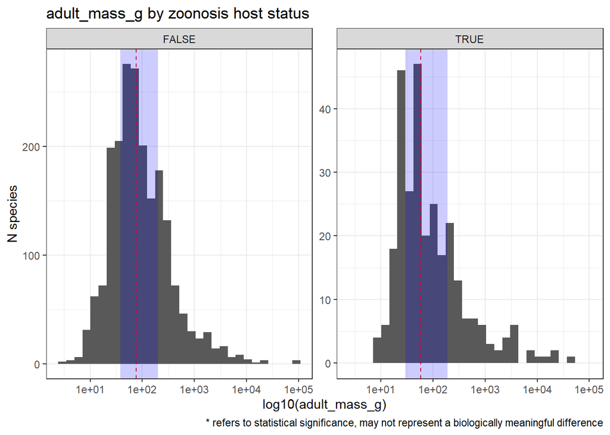

```
$quartiles
# A tibble: 2 × 6
  pathogen_status median_value lower_quartile upper_quartile significant p_value
  <lgl>                  <dbl>          <dbl>          <dbl> <chr>         <dbl>
1 FALSE                  1319.          1041.          1946. *           0.00026
2 TRUE                   1533           1093.          2377. *           0.00026

$p_value
[1] 0.0002590712
```

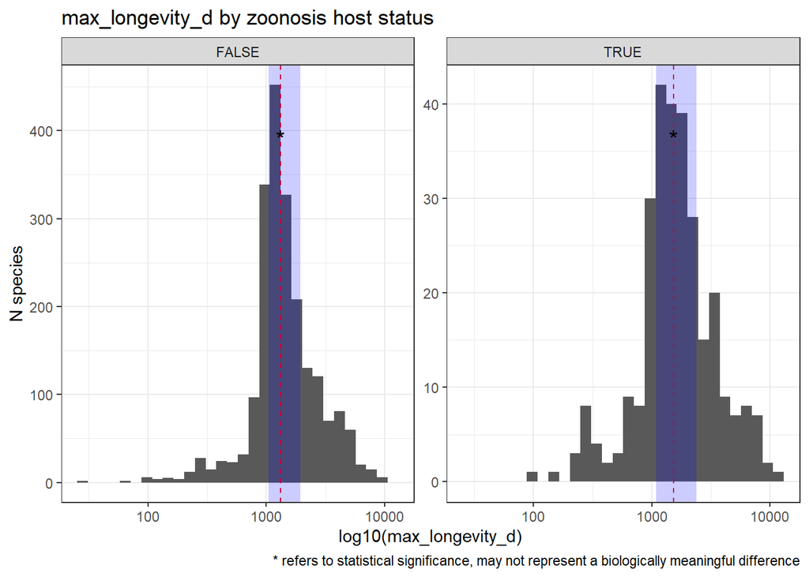

```
$quartiles
# A tibble: 2 × 6
  pathogen_status median_value lower_quartile upper_quartile significant p_value
  <lgl>                  <dbl>          <dbl>          <dbl> <chr>         <dbl>
1 FALSE                   30.1           25.9           40.0 *                 0
2 TRUE                    26.9           23.4           31.8 *                 0

$p_value
[1] 7.433135e-12
```

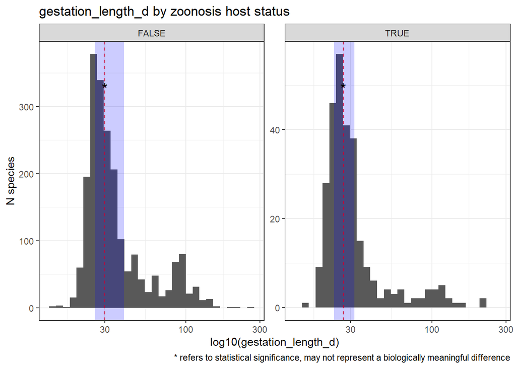

```
$quartiles
# A tibble: 2 × 6
  pathogen_status median_value lower_quartile upper_quartile significant p_value
  <lgl>                  <dbl>          <dbl>          <dbl> <chr>         <dbl>
1 FALSE                   3.1            2.37           3.87 *                 0
2 TRUE                    3.86           2.92           4.99 *                 0

$p_value
[1] 4.339365e-17
```

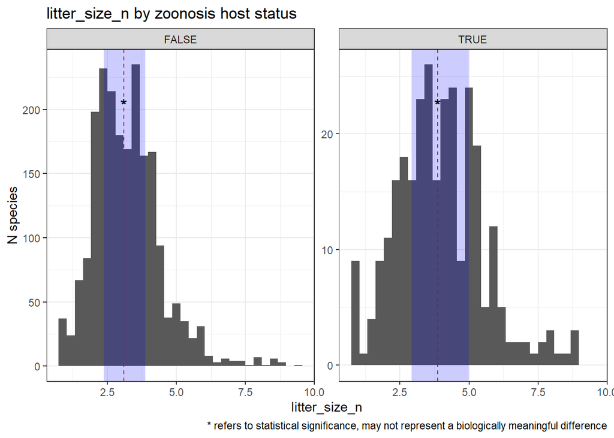

```
$quartiles
# A tibble: 2 × 6
  pathogen_status median_value lower_quartile upper_quartile significant p_value
  <lgl>                  <dbl>          <dbl>          <dbl> <chr>         <dbl>
1 FALSE                   3.04           1.89           3.46 *           0.00109
2 TRUE                    3.21           2              3.85 *           0.00109

$p_value
[1] 0.001085477
```

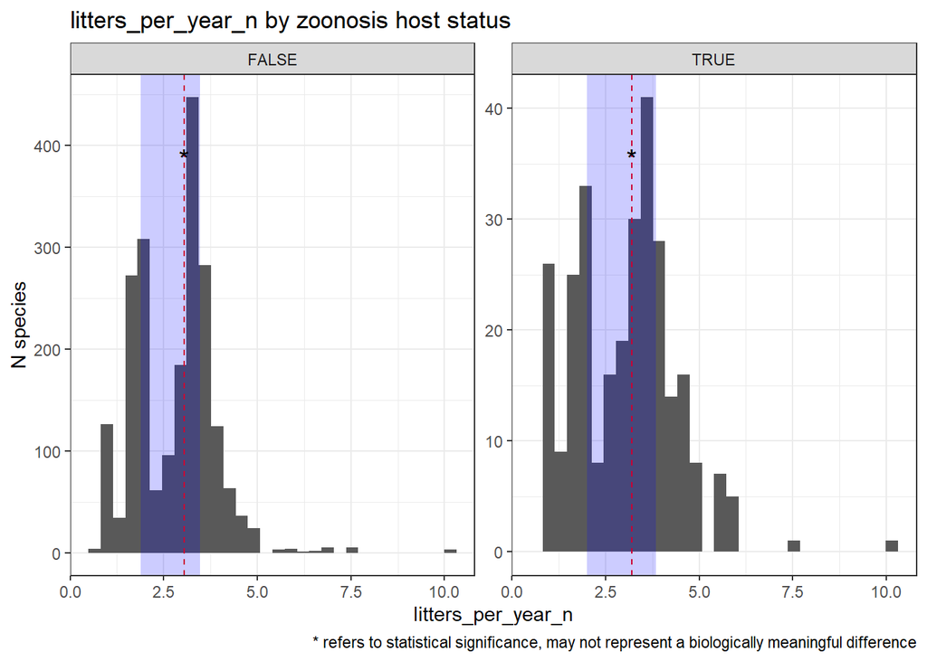

```r
rodent_trait <- read_csv(here("data", "combine", "trait_data_imputed.csv")) %>%
  mutate(iucn2020_binomial = str_to_lower(iucn2020_binomial)) %>%
  filter(order == "Rodentia")


# Are rodent hosts different from non-hosts in their life span or reproductive output?
rodent_hosts <- clover_data$rodentia_clover %>%
  group_by(Host, PathogenType)  %>%
  summarise(n = n(), .groups = "drop") %>%
  pivot_wider(names_from = PathogenType, values_from = n) %>%
  mutate(across(.cols = everything(), .fns = ~ replace_na(.x, 0))) %>%
  mutate(Host = case_when(str_detect(Host, "alexandromys middendorffii") ~ "microtus middendorffii",
                          str_detect(Host, "bolomys amoenus") ~ "necromys amoenus",
                          str_detect(Host, "dipodillus campestris") ~ "gerbillus campestris",
                          str_detect(Host, "dipodillus dasyurus") ~ "gerbillus dasyurus",
                          str_detect(Host, "eothenomys eleusis") ~ "thomasomys eleusis",
                          str_detect(Host, "liomys adspersus") ~ "heteromys adspersus",
                          str_detect(Host, "liomys salvini") ~ "heteromys salvini",
                          str_detect(Host, "myotomys unisulcatus") ~ "otomys unisulcatus",
                          str_detect(Host, "neodon fuscus") ~ "lasiopodomys fuscus",
                          str_detect(Host, "orientallactaga sibirica") ~ "allactaga sibirica",
                          str_detect(Host, "rattus flavipectus") ~ "rattus tanezumi",
                          str_detect(Host, "^tamias") ~ str_replace(Host, "^tamias", "neotamias"),
                          str_detect(Host, "terricola subterraneus") ~ "microtus subterraneus",
                          TRUE ~ Host),
         Host = case_when(str_detect(Host, "neotamias striatus") ~ "tamias striatus",
                          str_detect(Host, "neotamiasciurus douglasii") ~ "tamiasciurus douglasii",
                          str_detect(Host, "neotamiasciurus hudsonicus") ~ "tamiasciurus hudsonicus",
                          TRUE ~ Host)) %>%
  rowwise() %>%
  mutate(n_pathogens = sum(virus, `bacteria/rickettsia`, protozoa, helminth, fungi))

present_hosts <- rodent_hosts$Host[rodent_hosts$Host %in% rodent_trait$iucn2020_binomial]
missing_hosts <- rodent_hosts$Host[!rodent_hosts$Host %in% rodent_trait$iucn2020_binomial]

trait_by_host <- left_join(rodent_trait,
          rodent_hosts %>%
            filter(virus >= 1),
          by = c("iucn2020_binomial" = "Host")) %>%
  select(iucn2020_binomial, adult_mass_g, max_longevity_d, gestation_length_d, litter_size_n, litters_per_year_n, n_pathogens, virus, `bacteria/rickettsia`, protozoa, helminth, fungi) %>%
  mutate(pathogen_status = case_when(is.na(n_pathogens) ~ FALSE,
                                     TRUE ~ TRUE))

# Function to perform Wilcoxon test and calculate quartiles
get_stats <- function(data, variable) {
  # Perform Wilcoxon test
  formula <- as.formula(paste(variable, "~ pathogen_status"))
  test_result <- wilcox.test(formula, data = data, exact = FALSE)
  p_value <- test_result$p.value

  # Calculate quartiles and add significance annotation
  quartiles <- data %>%
    group_by(pathogen_status) %>%
    summarise(
      median_value = median(.data[[variable]], na.rm = TRUE),
      lower_quartile = quantile(.data[[variable]], 0.25, na.rm = TRUE),
      upper_quartile = quantile(.data[[variable]], 0.75, na.rm = TRUE)
    ) %>%
    mutate(significant = ifelse(p_value < 0.05, "*", ""),
           p_value = round(p_value, 5))

  list(quartiles = quartiles, p_value = p_value)
}

# List of variables to analyze
variables <- c("adult_mass_g", "max_longevity_d", "gestation_length_d",
               "litter_size_n", "litters_per_year_n")
# Variables that require log transformation on the x-axis
log_transform_vars <- c("adult_mass_g", "max_longevity_d", "gestation_length_d")

# Loop through each variable and create plots
for (variable in variables) {
  # Get statistics for the current variable
  stats <- get_stats(trait_by_host, variable)
  print(stats)

  # Generate the plot
  p <- ggplot(data = trait_by_host) +
    geom_histogram(aes_string(x = variable), bins = 30) +
    geom_vline(data = stats$quartiles, aes(xintercept = median_value), colour = "red", linetype = "dashed") +
    geom_rect(data = stats$quartiles, aes(xmin = lower_quartile,
                                          xmax = upper_quartile,
                                          ymin = -Inf,
                                          ymax = Inf), fill = "blue", alpha = 0.2) +
    geom_text(data = stats$quartiles, aes(x = median_value,
                                          y = -0.1,
                                          label = significant),
              vjust = -20, # Position the star above the median line
              colour = "black",
              size = 5) +
    facet_wrap(~ pathogen_status, scales = "free_y") +
    {if (variable %in% log_transform_vars) scale_x_log10() else NULL} +
    labs(y = "N species",
         x = paste(if (variable %in% log_transform_vars) "log10(" else "", variable, if (variable %in% log_transform_vars) ")"
                   else "", sep = ""),
         title = paste(variable, "by zoonosis host status"),
         caption = paste("* refers to statistical significance, may not represent a biologically meaningful difference")) +
    theme_bw()

  print(p)  # Display the plot
}
```